# Chapter 8: Hierarchical model construction

## Big picture

Translating problems to models is a key skill, and it may take a fair bit of practice. In this chapter we introduce tools to help with this step: parameter, process, and observation models, and a few examples that make use of familiar probability distributions.

#### Learning goals

- building models from simple submodels
- parameter, process, and observation models
- examples:  
  – occupancy model  
  – N-mixture model  
  – error in variables models

## Parameter, process, and observation models

One incredibly powerful perspective in model construction is the distinction between observation, process, and parameter models. The observation model includes the likelihood, and relates the latent process of interest to the quantities that we have actually observed. The process model is typically what we’re most interested in scientifically, and typically is not fully observed. The parameter model includes any hierarchical structures on parameters and priors for hyperparameters.

### Example: occupancy model

In occupancy models, we make binary observations (detected, not detected) on latent binary quantities (present, not present), and we must have priors for the detection and occurrence parameters to complete a Bayesian formulation (the parameter model). If we visit sites $i=1, ..., n$, and conduct $j=1, ..., J$ surveys at each then we can write out these components as follows:

**Observation model**

Here our detection and nondetection data $y$ arise as a function of the latent occurrence state $z$ and probability of detection $p$.

$y_{ij} \sim Bern(J, z_i p_{ij})$

**Process model**

Here, the species is present $z=1$ or absent $z=0$ with some probability $\psi$.

$z_i \sim Bern(\psi_i)$

**Parameter model**

Finally, priors are specified for the occurrence and detection probabilities.

$\psi_i \sim ...$

$p_{ij} \sim ...$

## Example: N-mixture model

We are often interested in estimating and explaining population sizes in wild organisms, and mark-recapture methods are not always feasible. Suppose we visit site $i$ multiple times $j=1, ..., J$, and on each visit we conduct a survey, recording the number of individuals observed. If we can assume that across visits, the true abundance $N_i$ is unchanged, and that the detection of each individual is imperfect but independent, then we might construct an N-mixture model to estimate abundance.

**Observation model**

We observe a subset of the individuals at the site, and each individual is detected with probability $p_i$:

$y_{ij} \sim Binom(N_i, p_i)$

Notice that both parameters of the binomial observation model are unknown. True abundance $N_i$ is a latent quantity.

**Process model**

We need some discrete probability distribution for $N$, such as the Poisson or negative binomial.

$N_i \sim Pois(\lambda_i)$

**Parameter model**

Finally, we need priors for $p$ and $\lambda$.

$p \sim ...$

$\lambda \sim ...$

We note that this model has integer parameters, and as such cannot be fitted (presently) with Stan, but this is easy to implement in JAGS.

## Error in variables models

Most of the time in ecology, covariates are observed with error and subsequently assumed to be known exactly. This causes bias in slope estimates, and despite the fact that this has been known for over a century, most people carry on assuming that the covariate is fixed.

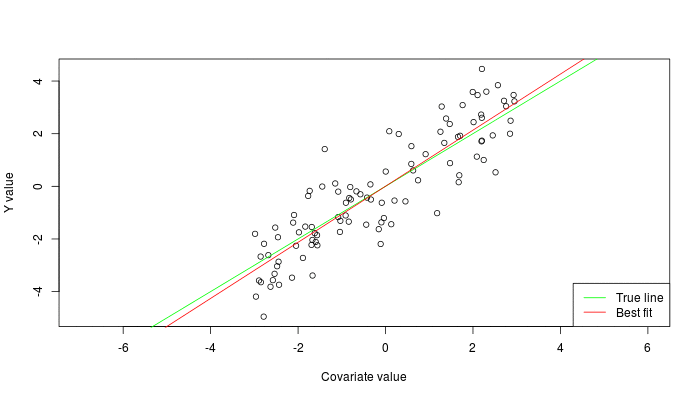

For what follows, we’ll assume a simple linear regression, in which continuous covariates are measured with error. But, this approach can be applied to any of the models that we’ve covered in this class.

True covariate values are considered latent variables, with repeated measurements of covariate values $x_{i=1}, ..., x_{i=n}$ arising from a normal distribution with a mean equal to the true value, and some measurement error $\sigma_x$. Again, this is a special case, but in principle the covariate could have other distributions (e.g., you’re interested in the effect of sex (M or F), but this is measured imperfectly).

Borrowing from some graphical tools common in structural equation modeling, we can represent the latent variables in the model as circles, and observables as boxes:

[figure not shown]

with $\epsilon_x \sim Normal(0, \sigma_x)$ and $\epsilon_y \sim Normal(0, \sigma_y)$.

**Observation model**

We assume that for sample unit $i$ and repeat measurement $j$:

$x^{obs}_{ij} \sim Normal(x_i, \sigma_x)$

$y \sim Normal(\mu_y, \sigma_y)$

The trick here is to use repeated measurements of the covariates to estimate and correct for measurement error. In order for this to be valid, the true covariate values cannot vary across repeat measurements. If the covariate was individual weight, you would have to ensure that the true weight did not vary across repeat measurements (for me, frogs urinating during handling would violate this assumption).

**Process model**

This is what we’re typically interested in: how the expected value of $y$ varies with $x$. In this case, $x$ is a parameter (it will require a prior).

$\mu_y = \alpha + \beta x_i$

**Parameter model**

In the parameter model, we would specify priors for $x$, $\alpha$, $\beta$, and the variance parameters. More on this example can be found [here](http://mbjoseph.github.io/2013/11/27/measure.html).